# Cyclistic Analysis

Mike Quach

2024-09-28

## Introduction

Cyclistic is a fictional bike-sharing company based in Chicago. The marketing director believes that the key to the company’s future success is to boost the conversion of casual riders into annual members. In order to achieve this we must determine and understand how subscribers and casual riders use the service differently.

## Ask

The marketing analytics team will be operating under the guidance of three questions:

1. How do annual members and casual riders use Cyclistic bikes differently?
2. Why would casual riders by Cyclistic annual membership?
3. How can Cyclistic use digital media to influence casual riders to become members?

The director has assigned us with the question: “How do annual members and casual riders use Cyclistic bikes differently?

## Hypothesis

Going into the analysis I had an assumption that casual riders just did not ride as often or as long as annual members. I anticipated that casual riders only needed a bike rental for quick trips and did not use it often or long enough to justify the price tag of an annual subscription.

## Findings

### Tableau

I exported the cleaned data to a CSV from R and imported it into Tableau. This allowed me to come to some other findings through connections with visualizations.

[Tableau Dashboard](https://public.tableau.com/views/CyclisticUsertypeComparisson/ComparisonofUsers?:language=en-US&publish=yes&:sid=&:redirect=auth&:display_count=n&:origin=viz_share_link)

We see from these visualizations that casual riders and annual members have different primary stations. We also see that in the summer months, interestingly enough we get an increase in unique trips starting in June and then sharply falling off after August. However, even with this spike we see that there is still nearly more than 2X the amount of annual member rides during August compared to casual riders.

## Recommendations

Our findings tell us that our casual riders and our annual members see different value propositions in our product. Annual members value them for short rides and our casual riders prefer longer rentals. I assume these preferences are due to the price structure of the annual membership and the current cost per rental for casual riders. Annual members can ride whenever and therefore have the leisure of taking short rides for small errands where as casual riders will probably want to get the most out of the cost of the rental and only rent it when necessary for long rides. The marketing team can target these casual riders by emphasizing the cost savings of a membership yearly in comparison to X amount of daily bike rentals. This will help the casual rider justify the cost and also possibly find the value of being able to rent a bike for small errands.

## R Walk Through Below

```r
library(tidyverse)
library(conflicted)
conflict_prefer("filter", "dplyr")
```

```
## [conflicted] Will prefer dplyr::filter over any other package.
```

```r
conflict_prefer("lag", "dplyr")
```

```
## [conflicted] Will prefer dplyr::lag over any other package.
```

```r
#Upload your datasets (csv files) here
q1_2020 <- read_csv("bike_data_2020_q1.csv")
q4_2019 <- read_csv("bike_data_2019_q4.csv")
q3_2019 <- read_csv("bike_data_2019_q3.csv")
q2_2019 <- read_csv("bike_data_2019_q2.csv")
(q1_2020 <- rename(q1_2020
                   ,trip_id = ride_id
                   ,start_time = started_at
                   ,end_time = ended_at
                   ,from_station_name = start_station_name
                   ,from_station_id = start_station_id
                   ,to_station_name = end_station_name
                   ,to_station_id = end_station_id
                   ,usertype = member_casual

))
```

```
## # A tibble: 426,887 × 13
##    trip_id          rideable_type start_time          end_time
##    <chr>            <chr>         <dttm>              <dttm>
##  1 EACB19130B0CDA4A docked_bike   2020-01-21 20:06:59 2020-01-21 20:14:30
##  2 8FED874C809DC021 docked_bike   2020-01-30 14:22:39 2020-01-30 14:26:22
##  3 789F3C21E472CA96 docked_bike   2020-01-09 19:29:26 2020-01-09 19:32:17
##  4 C9A388DAC6ABF313 docked_bike   2020-01-06 16:17:07 2020-01-06 16:25:56
##  5 943BC3CBECCFD662 docked_bike   2020-01-30 08:37:16 2020-01-30 08:42:48
##  6 6D9C8A6938165C11 docked_bike   2020-01-10 12:33:05 2020-01-10 12:37:54
##  7 31EB9B8F406D4C82 docked_bike   2020-01-10 13:07:35 2020-01-10 13:12:24
##  8 A2B24E3F9C9720E3 docked_bike   2020-01-10 07:24:53 2020-01-10 07:29:50
##  9 5E3F01E1441730B7 docked_bike   2020-01-31 16:37:16 2020-01-31 16:42:11
## 10 19DC57F7E3140131 docked_bike   2020-01-31 09:39:17 2020-01-31 09:42:40
## # ℹ 426,877 more rows
## # ℹ 9 more variables: from_station_name <chr>, from_station_id <dbl>,
## #   to_station_name <chr>, to_station_id <dbl>, start_lat <dbl>,
## #   start_lng <dbl>, end_lat <dbl>, end_lng <dbl>, usertype <chr>
```

```r
(q2_2019 <- rename(q2_2019
                   ,trip_id = `01 - Rental Details Rental ID`
                   ,start_time = `01 - Rental Details Local Start Time`
                   ,end_time = `01 - Rental Details Local End Time`
                   ,from_station_name = `03 - Rental Start Station Name`
                   ,from_station_id = `03 - Rental Start Station ID`
                   ,to_station_name = `02 - Rental End Station Name`
                   ,to_station_id = `02 - Rental End Station ID`
                   ,usertype = `User Type`
                   ,bikeid = `01 - Rental Details Bike ID`
                   ,gender = `Member Gender`
                   ,birthyear = `05 - Member Details Member Birthday Year`
                   ,tripduration = `01 - Rental Details Duration In Seconds Uncapped`
))
```

```
## # A tibble: 1,108,163 × 12
##     trip_id start_time          end_time            bikeid tripduration
##       <dbl> <dttm>              <dttm>               <dbl>        <dbl>
##  1 22178529 2019-04-01 00:02:22 2019-04-01 00:09:48   6251          446
##  2 22178530 2019-04-01 00:03:02 2019-04-01 00:20:30   6226         1048
##  3 22178531 2019-04-01 00:11:07 2019-04-01 00:15:19   5649          252
##  4 22178532 2019-04-01 00:13:01 2019-04-01 00:18:58   4151          357
##  5 22178533 2019-04-01 00:19:26 2019-04-01 00:36:13   3270         1007
##  6 22178534 2019-04-01 00:19:39 2019-04-01 00:23:56   3123          257
##  7 22178535 2019-04-01 00:26:33 2019-04-01 00:35:41   6418          548
##  8 22178536 2019-04-01 00:29:48 2019-04-01 00:36:11   4513          383
##  9 22178537 2019-04-01 00:32:07 2019-04-01 01:07:44   3280         2137
## 10 22178538 2019-04-01 00:32:19 2019-04-01 01:07:39   5534         2120
## # ℹ 1,108,153 more rows
## # ℹ 7 more variables: from_station_id <dbl>, from_station_name <chr>,
## #   to_station_id <dbl>, to_station_name <chr>, usertype <chr>, gender <chr>,
## #   birthyear <dbl>
```

```r
q1_2020 <-  mutate(q1_2020, trip_id = as.character(trip_id))
q4_2019 <-  mutate(q4_2019, trip_id = as.character(trip_id))
q3_2019 <-  mutate(q3_2019, trip_id = as.character(trip_id))
q2_2019 <-  mutate(q2_2019, trip_id = as.character(trip_id))
```

```r
all_trips <- bind_rows(q1_2020, q4_2019, q3_2019, q2_2019)
head(all_trips)
```

```
## # A tibble: 6 × 17
##   trip_id          rideable_type start_time          end_time
##   <chr>            <chr>         <dttm>              <dttm>
## 1 EACB19130B0CDA4A docked_bike   2020-01-21 20:06:59 2020-01-21 20:14:30
## 2 8FED874C809DC021 docked_bike   2020-01-30 14:22:39 2020-01-30 14:26:22
## 3 789F3C21E472CA96 docked_bike   2020-01-09 19:29:26 2020-01-09 19:32:17
## 4 C9A388DAC6ABF313 docked_bike   2020-01-06 16:17:07 2020-01-06 16:25:56
## 5 943BC3CBECCFD662 docked_bike   2020-01-30 08:37:16 2020-01-30 08:42:48
## 6 6D9C8A6938165C11 docked_bike   2020-01-10 12:33:05 2020-01-10 12:37:54
## # ℹ 13 more variables: from_station_name <chr>, from_station_id <dbl>,
## #   to_station_name <chr>, to_station_id <dbl>, start_lat <dbl>,
## #   start_lng <dbl>, end_lat <dbl>, end_lng <dbl>, usertype <chr>,
## #   bikeid <dbl>, tripduration <dbl>, gender <chr>, birthyear <dbl>
```

```r
all_trips <- all_trips %>%
  select(-c(start_lat, start_lng, end_lat, end_lng, birthyear, gender, tripduration, bikeid, rideable_type))
head(all_trips)
```

```
## # A tibble: 6 × 8
##   trip_id          start_time          end_time            from_station_name
##   <chr>            <dttm>              <dttm>              <chr>
## 1 EACB19130B0CDA4A 2020-01-21 20:06:59 2020-01-21 20:14:30 Western Ave & Leland…
## 2 8FED874C809DC021 2020-01-30 14:22:39 2020-01-30 14:26:22 Clark St & Montrose …
## 3 789F3C21E472CA96 2020-01-09 19:29:26 2020-01-09 19:32:17 Broadway & Belmont A…
## 4 C9A388DAC6ABF313 2020-01-06 16:17:07 2020-01-06 16:25:56 Clark St & Randolph …
## 5 943BC3CBECCFD662 2020-01-30 08:37:16 2020-01-30 08:42:48 Clinton St & Lake St
## 6 6D9C8A6938165C11 2020-01-10 12:33:05 2020-01-10 12:37:54 Wells St & Hubbard St
## # ℹ 4 more variables: from_station_id <dbl>, to_station_name <chr>,
## #   to_station_id <dbl>, usertype <chr>
```

```r
all_trips <-  all_trips %>%
  mutate(usertype = recode(usertype
                                ,"Subscriber" = "member"
                                ,"Customer" = "casual"))
```

```r
table(all_trips$usertype)
```

```
##
##  casual  member
##  905954 2973868
```

```r
all_trips$date <- as.Date(all_trips$start_time) #The default format is yyyy-mm-dd
all_trips$month <- format(as.Date(all_trips$date), "%m")
all_trips$day <- format(as.Date(all_trips$date), "%d")
all_trips$year <- format(as.Date(all_trips$date), "%Y")
all_trips$day_of_week <- format(as.Date(all_trips$date), "%A")
```

```r
all_trips$ride_length <- difftime(all_trips$end_time,all_trips$start_time)
```

```r
# this allows you to run calculations on this
is.factor(all_trips$ride_length)
```

```
## [1] FALSE
```

```r
all_trips$ride_length <- as.numeric(as.character(all_trips$ride_length))
is.numeric(all_trips$ride_length)
```

```
## [1] TRUE
```

```r
all_trips_v2 <- all_trips[!(all_trips$from_station_name == "HQ QR" | all_trips$ride_length<0),]
```

```r
summary(all_trips_v2$ride_length)
```

```
##    Min. 1st Qu.  Median    Mean 3rd Qu.    Max.
##       1     412     712    1479    1289 9387024
```

```r
aggregate(all_trips_v2$ride_length ~ all_trips_v2$usertype, FUN = mean)
```

```
##   all_trips_v2$usertype all_trips_v2$ride_length
## 1                casual                3552.7502
## 2                member                 850.0662
```

```r
aggregate(all_trips_v2$ride_length ~ all_trips_v2$usertype, FUN = median)
```

```
##   all_trips_v2$usertype all_trips_v2$ride_length
## 1                casual                     1546
## 2                member                      589
```

```r
aggregate(all_trips_v2$ride_length ~ all_trips_v2$usertype, FUN = max)
```

```
##   all_trips_v2$usertype all_trips_v2$ride_length
## 1                casual                  9387024
## 2                member                  9056634
```

```r
aggregate(all_trips_v2$ride_length ~ all_trips_v2$usertype, FUN = min)
```

```
##   all_trips_v2$usertype all_trips_v2$ride_length
## 1                casual                        2
## 2                member                        1
```

```r
aggregate(all_trips_v2$ride_length ~ all_trips_v2$usertype + all_trips_v2$day_of_week, FUN = mean)
```

```
##    all_trips_v2$usertype all_trips_v2$day_of_week all_trips_v2$ride_length
## 1                 casual                   Friday                3773.8351
## 2                 member                   Friday                 824.5305
## 3                 casual                   Monday                3372.2869
## 4                 member                   Monday                 842.5726
## 5                 casual                 Saturday                3331.9138
## 6                 member                 Saturday                 968.9337
## 7                 casual                   Sunday                3581.4054
## 8                 member                   Sunday                 919.9746
## 9                 casual                 Thursday                3682.9847
## 10                member                 Thursday                 823.9278
## 11                casual                  Tuesday                3596.3599
## 12                member                  Tuesday                 826.1427
## 13                casual                Wednesday                3718.6619
## 14                member                Wednesday                 823.9996
```

```r
all_trips_v2$day_of_week <- ordered(all_trips_v2$day_of_week, levels=c("Sunday", "Monday", "Tuesday", "Wednesday", "Thursday", "Friday", "Saturday"))
```

```r
aggregate(all_trips_v2$ride_length ~ all_trips_v2$usertype + all_trips_v2$day_of_week, FUN = mean)
```

```
##    all_trips_v2$usertype all_trips_v2$day_of_week all_trips_v2$ride_length
## 1                 casual                   Sunday                3581.4054
## 2                 member                   Sunday                 919.9746
## 3                 casual                   Monday                3372.2869
## 4                 member                   Monday                 842.5726
## 5                 casual                  Tuesday                3596.3599
## 6                 member                  Tuesday                 826.1427
## 7                 casual                Wednesday                3718.6619
## 8                 member                Wednesday                 823.9996
## 9                 casual                 Thursday                3682.9847
## 10                member                 Thursday                 823.9278
## 11                casual                   Friday                3773.8351
## 12                member                   Friday                 824.5305
## 13                casual                 Saturday                3331.9138
## 14                member                 Saturday                 968.9337
```

```r
all_trips_v2 %>%
  mutate(weekday = wday(start_time, label = TRUE)) %>%  #creates weekday field using wday()
  group_by(usertype, weekday) %>%  #groups by usertype and weekday
  summarise(number_of_rides = n()                           #calculates the number of rides and average duration
            ,average_duration = mean(ride_length)) %>%      # calculates the average duration
  arrange(usertype, weekday)                                # sorts
```

```
## # A tibble: 14 × 4
## # Groups:   usertype [2]
##    usertype weekday number_of_rides average_duration
##    <chr>    <ord>             <int>            <dbl>
##  1 casual   Sun              181293            3581.
##  2 casual   Mon              103296            3372.
##  3 casual   Tue               90510            3596.
##  4 casual   Wed               92457            3719.
##  5 casual   Thu              102679            3683.
##  6 casual   Fri              122404            3774.
##  7 casual   Sat              209543            3332.
##  8 member   Sun              267965             920.
##  9 member   Mon              472196             843.
## 10 member   Tue              508445             826.
## 11 member   Wed              500329             824.
## 12 member   Thu              484177             824.
## 13 member   Fri              452790             825.
## 14 member   Sat              287958             969.
```

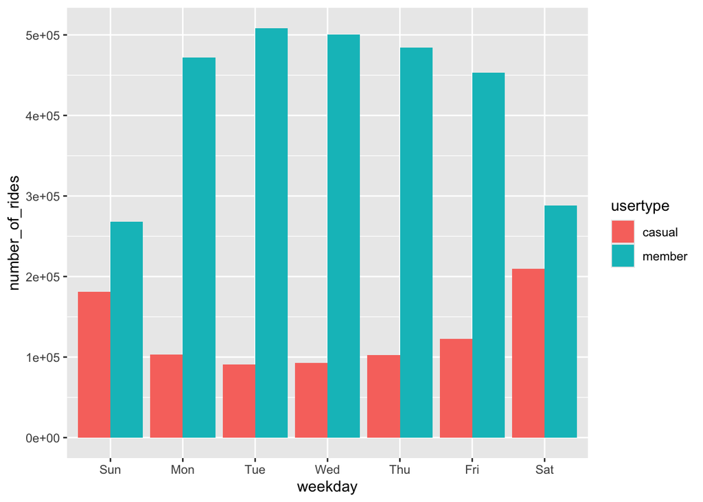

```r
all_trips_v2 %>%
  mutate(weekday = wday(start_time, label = TRUE)) %>%
  group_by(usertype, weekday) %>%
  summarise(number_of_rides = n()
            ,average_duration = mean(ride_length)) %>%
  arrange(usertype, weekday)  %>%
  ggplot(aes(x = weekday, y = number_of_rides, fill = usertype)) +
  geom_col(position = "dodge")
```

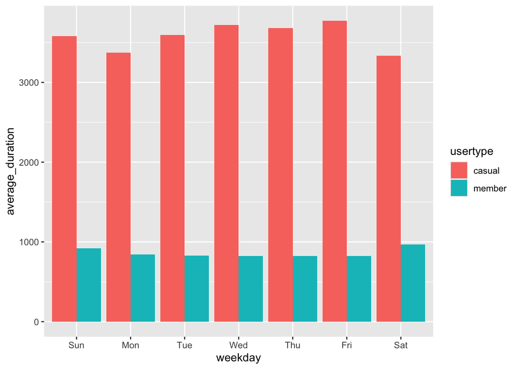

```r
all_trips_v2 %>%
  mutate(weekday = wday(start_time, label = TRUE)) %>%
  group_by(usertype, weekday) %>%
  summarise(number_of_rides = n()
            ,average_duration = mean(ride_length)) %>%
  arrange(usertype, weekday)  %>%
  ggplot(aes(x = weekday, y = average_duration, fill = usertype)) +
  geom_col(position = "dodge")
```

```r
# please be mindful of your working directory
counts <- aggregate(all_trips_v2$ride_length ~ all_trips_v2$usertype + all_trips_v2$day_of_week, FUN = mean)
write.csv(counts, file = 'avg_ride_length.csv')

write.csv(all_trips_v2, file = 'all_trips_v2.csv')
```